7. Θεωρείστε το σύνολο δεδομένων faithful και εκτιμήστε την επόμενη έκρηξη αν ο αναμενόμενος χρόνος από την τελευταία έκρηξη είναι 80 λεπτά. Να βρεθεί ο συντελεστής προσδιορισμού και η ευθεία παλινδρόμησης. Ελέγξτε αν υπάρχει στατιστικά σημαντική σχέση μεταξύ των δύο μεταβλητών στο μοντέλο της ευθείας παλινδρόμησης για τις δύο μεταβλητές των δεδομένων σας με επίπεδο σημαντικότητας α=0.05. Κατασκευάστε ένα 95% Δ.Ε. για την μεταβλητή eruption duration για δεδομένο χρόνο αναμονής 80 min. Κατασκευάστε ένα 95% διάστημα πρόβλεψης της μεταβλητής eruption duration δεδομένο χρόνο αναμονής 80 min. Επιπλέον να γίνει το διάγραμμα υπολοίπων της γραμμικής παλινδρόμησης έναντι της μεταβλητής waiting. Να γίνει το διάγραμμα της κανονικότητας για τα τυποποιημένα υπόλοιπα της γραμμικής παλινδρόμησης.

**Perigrafi Dedomenon** Waiting time between eruptions and the duration of the eruption for the Old Faithful geyser in Yellowstone National Park, Wyoming, USA. - H stili eruptions: Anaparista ton xrono pou dierkise i ekriksi tou ifestiou - To xaraktiristiko waiting anaparista ton xrono apo tin mia ekriksi mexri tin epomeni.

**Zitoumena tis askisis** Skopos mas einai na provlepsoume tin diarkia pou tha exei i epomeni ekriksi dedomenou oti tha ginei se 80 lepta.

## Load dataset

- Arxika fortonoume to dataset prosdiorizontas oti i proti grami einai headr
- stin sinexia provaloume ta dedomena.

```r
# load dataset
data <- read.table('./datasets/faithfull.txt', header = 1)
data
```

```
##     eruptions waiting
## 1       3.600      79
## 2       1.800      54
## 3       3.333      74
## 4       2.283      62
## 5       4.533      85
## 6       2.883      55
## 7       4.700      88
## 8       3.600      85
## 9       1.950      51
## 10      4.350      85
## 11      1.833      54
## 12      3.917      84
## 13      4.200      78
## 14      1.750      47
```

[output cut: 258 more lines]

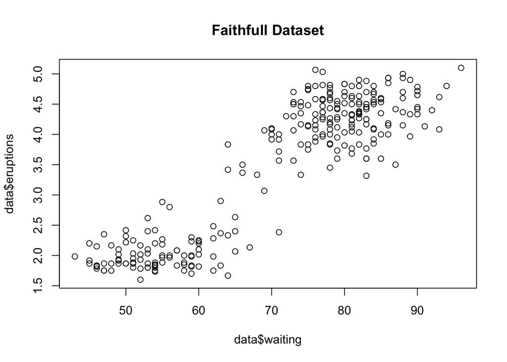

```r
#plot dataset
plot(data$waiting, data$eruptions, main = "Faithfull Dataset")
```